# Bangladesh surveillance greyspots

February 27, 2020

Elonia

# Introduction

The goal of this study is to identify how well the Bangladesh national cholera surveillance system captures:

1. the Bangladeshi population
2. the Bangladeshi population living in high, medium, and low risk cholera areas

Hospitals in the national cholera surveillance system and icddr,b Dhaka hospital are the only healthcare facilities that regularly perform laboratory confirmation of *V. cholerae* in Bangladesh. Consequently it is important to understand how well areas with high cholera risk are captured by the surveillance system.

# Methods

## Identifying the cholera surveillance zone

There are 23 hospital sites that perform laboratory confirmation of *V. cholerae* in Bangladesh (Table 1).

Table 1: **Sentinel hospital IDs and locations.**

| ID | Hospital | Division | Type |
| --- | --- | --- | --- |
| 1 | District Hospital Norshingdi | Dhaka | district |
| 2 | Adhunik Sadar Hospital Habiganj | Sylhet | district |
| 3 | District Sadar Hospital Cox’s Bazar | Chittagong | district |
| 4 | Adhunik Sadar Hospital Naogaon | Rajshahi | district |
| 5 | General Hospital Patuakhali | Barisal | tertiary |
| 6 | Adhunik Sadar Hospital Thakurgaon | Rangpur | district |
| 7 | District Sadar Hospital Satkhira | Khulna | district |
| 8 | Dhaka Medical College Dhaka | Dhaka | tertiary |
| 9 | Uttara Adhunik Medical College Hospital | Dhaka | tertiary |
| 10 | Bangladesh Institute of Tropical and Infectious Diseases Chittagong | Chittagong | tertiary |
| 11 | General Hospital Tangail | Dhaka | district |
| 12 | General Hospital Narayanganj | Dhaka | district |
| 13 | Sadar Hospital Chuadanga | Khulna | district |
| 14 | General Hospital Meherpur | Khulna | district |
| 15 | General Hospital Comilla | Chittagong | district |
| 16 | Upazila Health Complex Chaugachha Jesssore | Khulna | subdistrict |
| 17 | General Hospital Kusthia | Khulna | district |
| 18 | Upazila Health Complex Madan | Mymensingh | subdistrict |
| 19 | Upazila Health Complex Chhatak Sunamganj | Sylhet | subdistrict |
| 20 | Upazila Health Complex Mathbariya | Barisal | subdistrict |
| 21 | Upazila Health Complex Bakerganj | Barisal | subdistrict |
| 22 | Health Complex Shibganj | Rajshahi | subdistrict |
| 23 | icddr,b Cholera Hospital | Dhaka | icddrb |

In the absence of better data on health care utilization around the hospital sentinel surveillance sites, we assumed that areas enclosed by circular buffers around subdistrict, district, tertiary care, and icddr,b Dhaka sentinel hospitals with radii of 10-20-30-30km could serve as proxies for potential hospital catchment areas (Figure 1). We refer to the joint set of buffers around all 23 hospitals as the “cholera surveillance zone” in Bangladesh.

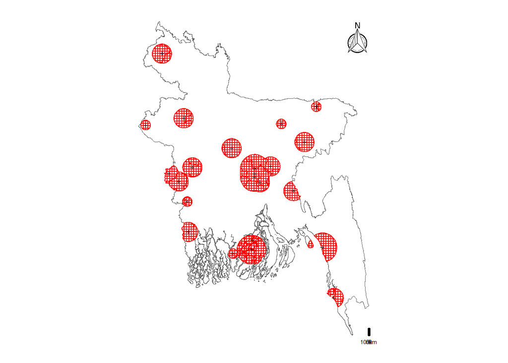

Figure 1: **Map of** 10-20-30-30km **buffers around subdistrict-district-tertiary-icddr,b sentinel hospital sites, respectively.**

## Defining risk of infection with *V. cholerae*

Although we have great uncertainty about the relative seroincidence risk across Bangladesh, our previous modeling efforts represent the best information we have about cholera risk in a given location. We used these modeling outputs to characterize the disease risk of populations living in *V. cholerae* greyspots.

Using the modeled seroincidence risk of infection with *V. cholerae*, we calculate three quantitative measures at the 5 km x 5 km grid cell level to represent risk of infection:

1. *Relative risk*: Median seroincidence risk at the grid cell level relative to the population-weighted mean seroincidence risk across Bangladesh. Relative risk of 1 indicates that the grid cell seroincidence risk is the same as the mean risk across the country.
2. *Proportion infected*: Median estimated proportion of the grid cell population that was infected with *V. cholerae* in the last year.
3. *Absolute infections*: Median estimated number of the grid cell population infected with *V. cholerae* in the last year.

For each of these measures, we identified thresholds by which we could partition grid cells into “high,” “moderate,” and “low” risk.

### Relative risk

We examined the distribution of relative risk and the width of the relative risk confidence interval estimates to determine if whether it might be possible to use this range to identify appropriate cutoffs.

```
## [1] "***** What is the distribution of relative risk estimates? *****"
```

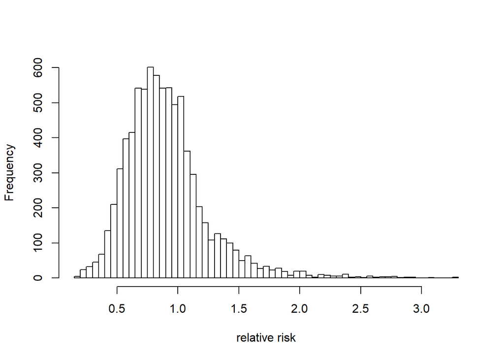

```
## [1] "summary stats on median relative risk: deciles"
```

```
##        0%       10%       20%       30%       40%       50%       60%       70%
## 0.1878425 0.5435891 0.6453819 0.7188687 0.7860784 0.8562672 0.9297886 1.0088887
##       80%       90%      100%
## 1.1000150 1.3103767 3.2647244
```

```
## [1] "What is the range of the relative risk estimates, where range is the width of the 95% CI?"
```

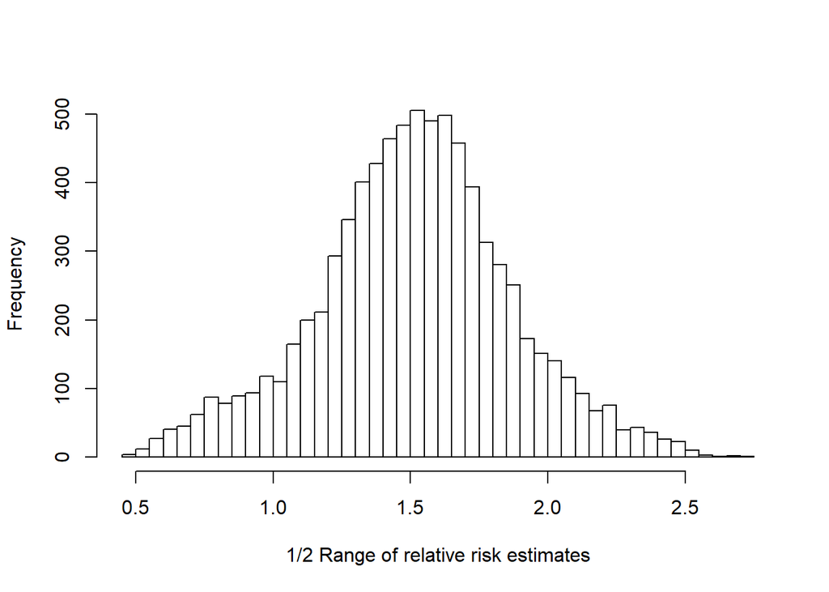

```
## [1] "summary stats on 1/2 range of RR: deciles"
```

```
##        0%       10%       20%       30%       40%       50%       60%       70%
## 0.4641809 1.0576451 1.2435192 1.3503377 1.4407787 1.5218541 1.6012463 1.6837145
##       80%       90%      100%
## 1.7904077 1.9615904 2.7042683
```

```
## [1] "Decision: Confidence interval ranges are too large to be useful. Arbitrarily choose relative risks of 0.8 and 1.2 as cutoffs"
```

We found that the confidence interval estimates were too large to be useful for this purpose. There was very high uncertainty in the relative seroincidence risk. Instead, we arbitrarily chose the relative risks of 0.8 and 1.2 as cutoffs for moderate and high risks.

### Proportion infected

We examined the distribution of the median proportion of the population infected and chose the 30th and 70th percentiles as cutoffs for moderate and high risk.

```
## [1] "***** What is the distribution of median proportion (of the population) infected within the last year? *****"
```

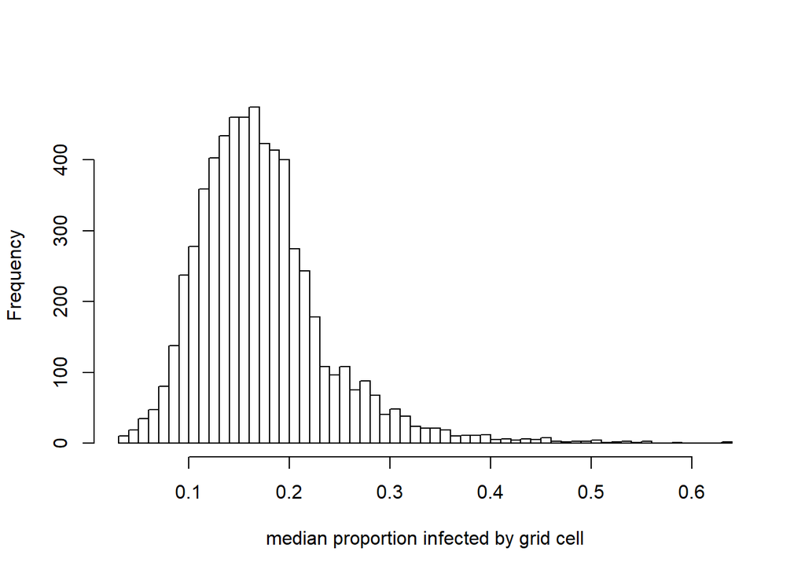

```
## [1] "summary stats on median proportion infected: deciles"
```

```
##         0%        10%        20%        30%        40%        50%        60%
## 0.03595797 0.10215108 0.12106694 0.13596771 0.14978710 0.16324129 0.17732849
##        70%        80%        90%       100%
## 0.19204748 0.21129631 0.25296893 0.63651462
```

```
## [1] "Decision: Use 30th and 70th percentiles as cutoffs"
```

### Absolute infections

We examined the distribution of the median number of absolute infections on the log10 scale and chose the 30th and 70th percentiles as cutoffs for moderate and high risk.

```
## [1] "***** What is the distribution of median infections within the last year? *****"
```

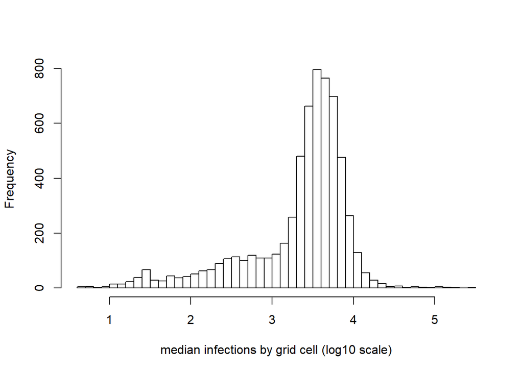

```
## [1] "summary stats on median infections: deciles"
```

```
##            0%           10%           20%           30%           40%
##      3.995863    251.563380    926.230252   2040.131620   2700.922748
##           50%           60%           70%           80%           90%
##   3291.225551   3954.858512   4758.848247   5804.953773   7447.174971
##          100%
## 252705.328285
```

```
## [1] "Decision: Use 30th and 70th percentiles as cutoffs"
```

# Results

## Population in the cholera surveillance zone

Table 2: **Population living in the cholera surveillance zone.**

| Buffer (Subdistrict-District-Tertiary-icddr,b in km) | Pop | Proportion |
| --- | --- | --- |
| 10-20-30-30 | 50887409 | 0.312939 |

## Identifying greyspots outside the cholera surveillance zone

Areas both that have large uncertainty in our seroincidence estimates and that are outside of the cholera surveillance zone are “greyspots,” locations about which no cholera-related information is known (Figure 3).

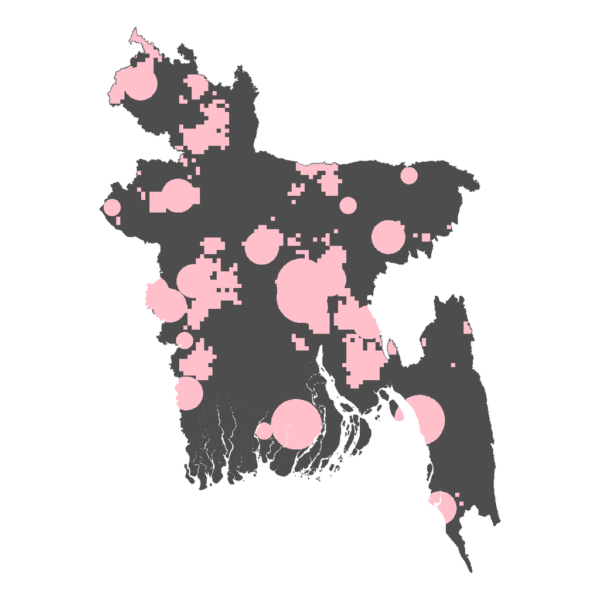

Figure 3: **Cholera greyspots.** The 5 km x 5 km grid cells that are colored in pink are cells where we have reasonably confidence seroincidence estimates (entropy < 0.3) or that are in the cholera surveillance zone. Grid cells in grey are greyspots, locations about which we have almost no cholera information.

## Relative seroincidence risk

Using data from a nationally-representative survey across Bangladesh, we developed maps of infection across 5 km x 5km cells in Bangladesh. This map estimates that, from the 2015 serosurvey data collection, there were 25651745.4614948 infections in Bangladesh over the past year out of an estimated population of 162611264.34846. We standardized the seroincidence estimates in each cell by the population-weighted mean of the Bangladesh infection rate in that cell. This yielded a relative risk of infection for each grid cell (Figure 4).

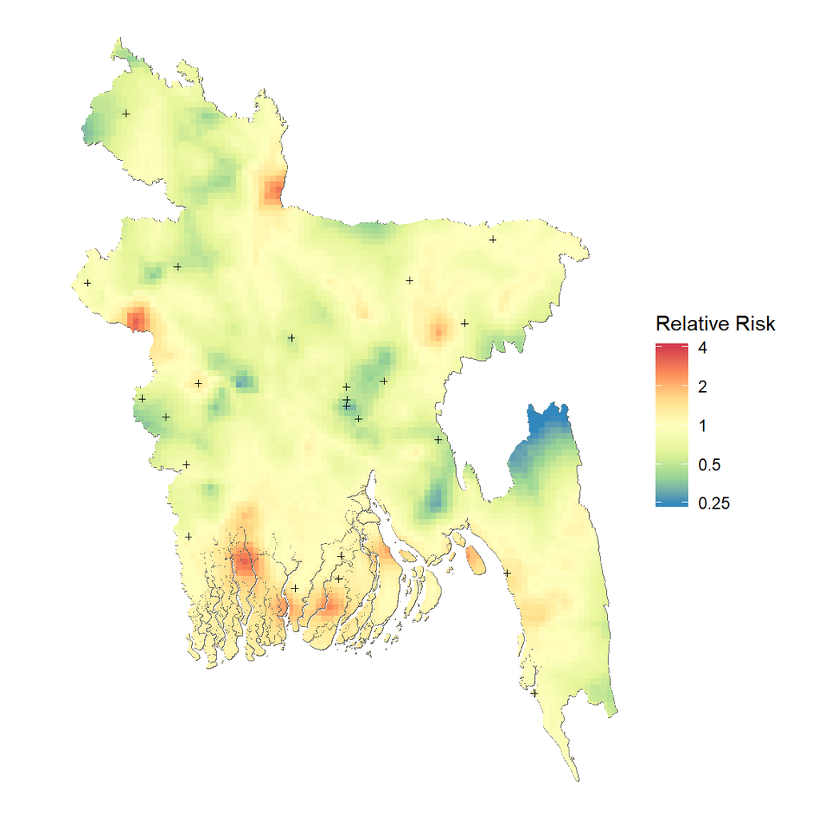

We describe the population living in each risk category (Table 3.)

Table 3: **Population living in each risk category.** The population living in high, moderate, and low risk areas according to relative seroincidence risk across Bangladesh.

| Risk Level | Population |
| --- | --- |
| High | 15198981 |
| Moderate | 63939131 |
| Low | 83473152 |

We redrew the relative seroincidence risk map after binning grid cells into high, moderate, and low risk categories (Figure 5).

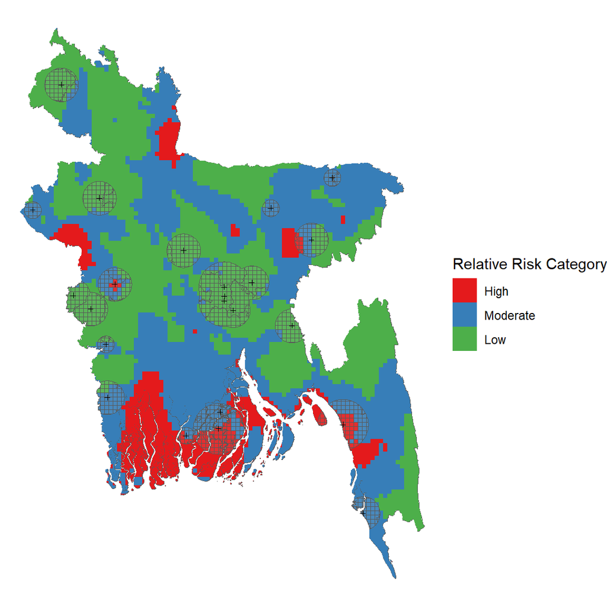

Figure 5: **Cholera risk map as categorized by the risk of seroincidence relative to a population-weighted mean by 5 km x 5 km grid cell.**

### Relative risk in the cholera surveillance zone

We overlaid the cholera surveillance zone with the binned relative seroincidence risk maps to examine the distribution of risks in the surveilled and non-surveilled areas (Figure 6 - Figure 7).

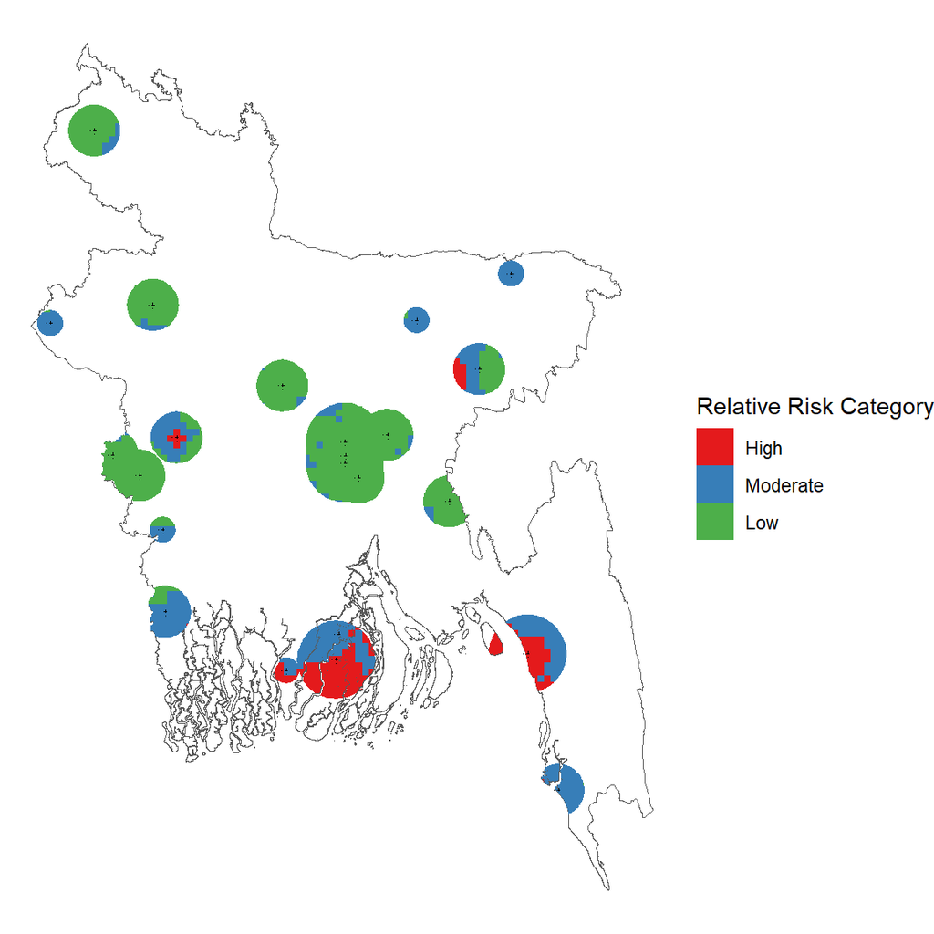

Figure 6: **Relative seroincidence risk within cholera surveillance zones (10-20-30-30km for subdistrict, district, and tertiary care, and icddr,b hospitals).**

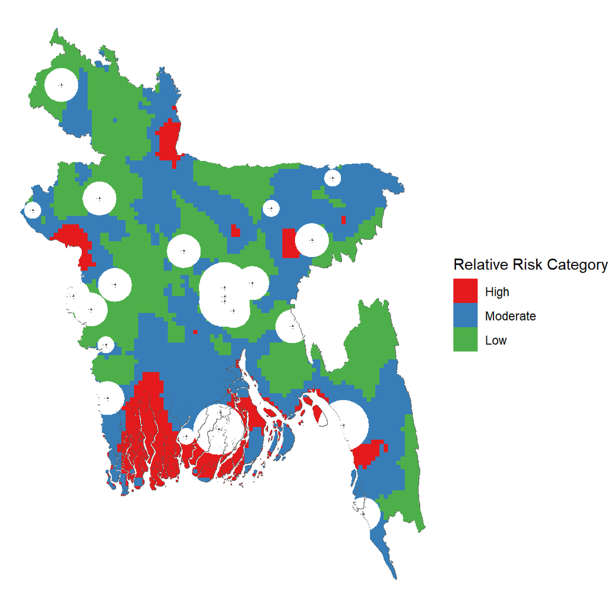

Figure 7: **Relative sero incidence risk outside of cholera surveillance zones (10-20-30-30km for subdistrict, district, tertiary care, and icddr,b hospitals).**

### Populations in the cholera surveillance zone

We examined the estimated number of infections, the percent infected in the cholera surveillance zone, and the percent of Bangladesh infections captured in the cholera surveillance zone (Table 4).

Table 4: **Number and percent infections that may be captured in cholera surveillance zones.** The percent infected represents the percentage of infected individuals captured within the cholera surveillance zone out of all infected individuals in Bangladesh.

| Buffer size | Surv. zone pop | Number infected | % infected in surv. zone pop | % of all BGD infections |
| --- | --- | --- | --- | --- |
| 10-20-30-30 | 50887409 | 7047294 | 13.85 | 27.47 |

We then examined the distribution of relative-risk-based categories (Table 5).

Table 5: **Number and percent infections that may be captured in cholera surveillance zones, categorized by relative risk.** The infections in surveillance zone represents the percentage of infected people in high/moderate/low risk grid cells among all infections within the cholera surveillance zone. The population in surveillance zone represents the percentage of people living in high/moderate/low risk grid cells among all people within the cholera surveillance zone. The distribution should across risk categories should sum to 100% for each set of buffer sizes.

| Buffer size | Risk category | Number infected | % surv. zone infections | Surv. zone pop | % BGD pop in surv. zone |
| --- | --- | --- | --- | --- | --- |
| 10-20-30-30 | High | 1532923 | 21.75 | 5657869 | 11.12 |
| 10-20-30-30 | Moderate | 1923614 | 27.30 | 10439618 | 20.52 |
| 10-20-30-30 | Low | 3590756 | 50.95 | 34789922 | 68.37 |

### Populations by relative risk across Bangladesh

We sought to describe how well the cholera surveillance zones capture High, Moderate, Low populations across the population of Bangladesh.

We summarized the percentage of high, moderate, and low infection risk populations in Bangladesh that would be captured by cholera surveillance zones at different buffer sizes when risk was categorized both by relative risk (Table 6).

Table 6: **Number and percent infections that may be captured in Bangladesh, categorized by relative risk.** The captured at-risk population represents the percentage of high/moderate/low risk populations captured by the cholera surveillance zone out of all high/moderate/low risk populations in Bangladesh. The captured infections represents the percentage of infections in high/moderate/low risk grid cells among all infections in high/moderate/low risk grid cells across Bangladesh.

| Buffer size | Risk category | Surv. zone pop | Surv. zone infections | Captured At-Risk Pop (%) | Captured Infections (%) |
| --- | --- | --- | --- | --- | --- |
| 10-20-30-30 | High | 5657869 | 1532923 | 37.23 | 33.52 |
| 10-20-30-30 | Moderate | 10439618 | 1923614 | 16.33 | 16.63 |
| 10-20-30-30 | Low | 34789922 | 3590756 | 41.68 | 37.74 |

# Discussion

- Can we use this method to evaluate how representative and sensitive is the system to capturing a proportion of cases?